# bundesliga-data-exploration

## Estrutura do Projeto:

1. Importação das Bibliotecas;
2. Carregamento da base de dados;
3. Visualização dos primeiros dados;
4. Compreensão das variáveis e seus comportamentos.
5. Exploração do dataframe e geração de insights.

```python
#instação das bibliotecas

#!pip install pandas
#!pip install missingno
#!pip install numpy
```

#### 📦 1. Importação das Bibliotecas

```python
#importar bibliotecas do python
import pandas as pd
import numpy as np
import csv
import seaborn as sns
import matplotlib.pyplot as plt
from matplotlib.ticker import StrMethodFormatter
import missingno as msno
import warnings
warnings.filterwarnings("ignore")
```

#### 📂 2. Carregamento da base de dados

```python
df = pd.read_csv("bundesliga_player.csv")
```

Carregamos os dados do arquivo `bundesliga_player.csv` em um DataFrame chamado `df`.

Antes de iniciar com os primeiros comandos, vamos compreender melhor as variáveis, usando o dicionário fornecido junto a essa base de dados no kaggle.

- `index`;
- `name`: The player's commonly known name;
- `full_name`: The player's full name;
- `age`: The player's age in years;
- `height`: The player's height in meters;
- `nationality`: The player's nationality;
- `place_of_birth`: The place where the player was born;
- `price`: The current price in millions;
- `max_price`: The maximum price the player ever had in millions;
- `position`: The player's position on the field;
- `shirt_nr`: The player's shirt number;
- `foot`: The player's preferred foot (left or right);
- `club`: The player's current club;
- `contract_expires`: The date when the player's contract with the current club expires;
- `joined_club`: The date when the player joined the current club;
- `player_agent`: The agent representing the player;
- `outfitter`: The brand or company that provides the player's sports gear.

#### 👀 3. Visualização dos primeiros dados

```python
pd.set_option('display.max_columns', None)  # Sem limite de colunas

df.head(5)
```

|  | Unnamed: 0 | name | full_name | age | height | nationality | place_of_birth | price | max_price | position | shirt_nr | foot | club | contract_expires | joined_club | player_agent | outfitter |
| --- | --- | --- | --- | --- | --- | --- | --- | --- | --- | --- | --- | --- | --- | --- | --- | --- | --- |
| 0 | 0 | Manuel Neuer | Manuel Peter Neuer | 37 | 1.93 | Germany | Gelsenkirchen | 7.0 | 45.0 | Goalkeeper | 1 | right | Bayern Munich | 2024-06-30 | 2011-07-01 | PRO Profil GmbH | adidas |
| 1 | 1 | Yann Sommer | NaN | 34 | 1.83 | Switzerland | Morges | 5.0 | 13.0 | Goalkeeper | 27 | right | Bayern Munich | 2025-06-30 | 2023-01-19 | Relatives | Puma |
| 2 | 2 | Sven Ulreich | NaN | 34 | 1.92 | Germany | Schorndorf | 0.9 | 6.0 | Goalkeeper | 26 | right | Bayern Munich | 2024-06-30 | 2021-07-01 | BMS Sportconsulting ... | adidas |
| 3 | 3 | Johannes Schenk | NaN | 20 | 1.91 | Germany | Schweinfurt | 0.3 | 0.3 | Goalkeeper | 35 | NaN | Bayern Munich | 2024-06-30 | 2022-07-01 | 11WINS | NaN |
| 4 | 4 | Matthijs de Ligt | NaN | 23 | 1.89 | Netherlands | Leiderdorp | 75.0 | 75.0 | Defender - Centre-Back | 4 | right | Bayern Munich | 2027-06-30 | 2022-07-19 | Rafaela Pimenta | adidas |

Este comando exibe as 5 primeiras linhas do DataFrame. É uma forma rápida de verificar a estrutura inicial da base e os tipos de dados contidos nela.

```python
df.info()
# ou display(df.dtypes)
```

```
<class 'pandas.core.frame.DataFrame'>
RangeIndex: 515 entries, 0 to 514
Data columns (total 17 columns):
 #   Column            Non-Null Count  Dtype
---  ------            --------------  -----
 0   Unnamed: 0        515 non-null    int64
 1   name              515 non-null    object
 2   full_name         229 non-null    object
 3   age               515 non-null    int64
 4   height            515 non-null    float64
 5   nationality       515 non-null    object
 6   place_of_birth    510 non-null    object
 7   price             510 non-null    float64
 8   max_price         510 non-null    float64
 9   position          515 non-null    object
 10  shirt_nr          515 non-null    int64
 11  foot              506 non-null    object
 12  club              515 non-null    object
 13  contract_expires  481 non-null    object
 14  joined_club       515 non-null    object
 15  player_agent      488 non-null    object
 16  outfitter         193 non-null    object
dtypes: float64(3), int64(3), object(11)
memory usage: 68.5+ KB
```

Aqui são exibidos os tipos de dados de cada coluna do DataFrame. Isso ajuda a identificar se os dados estão no formato correto (ex: datas como datetime, números como int/float).

Vemos no `df` que temos duas variáveis de *data* formatadas como *object*, são elas `contract_expires` e `joined_club`.

```python
df['contract_expires'] = pd.to_datetime(df['contract_expires'])
df['joined_club'] = pd.to_datetime(df['joined_club'])
```

```python
df.dtypes
```

```
Unnamed: 0                   int64
name                        object
full_name                   object
age                          int64
height                     float64
nationality                 object
place_of_birth              object
price                      float64
max_price                  float64
position                    object
shirt_nr                     int64
foot                        object
club                        object
contract_expires    datetime64[ns]
joined_club         datetime64[ns]
player_agent                object
outfitter                   object
dtype: object
```

Variáveis ajustadas para *datetime*.

```python
df.shape
```

```
(515, 17)
```

`df.shape` retorna a quantidade de linhas e colunas da base de dados.

```python
#visualizar duplicatas

df.duplicated()
```

```
0      False
1      False
2      False
3      False
4      False
       ...
510    False
511    False
512    False
513    False
514    False
Length: 515, dtype: bool
```

`df.duplicated` retorna as duplicatas. É uma boa prática verificar se existem dados duplicados.

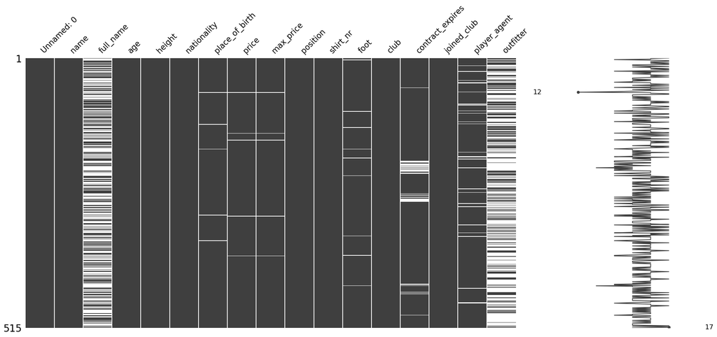

```python
msno.matrix(df, width_ratios=(3,1))
plt.show()
```

Aqui, observamos se há presença de valores faltantes (`missing values`) e o quanto representam em nosso dataframe.  
Valores ausentes podem representar baixa **confiabilidade** da base e possíveis **inconsistências**.

Através do gráfico gerado, é perceptível que temos duas variáveis com maior número de `missing values`, sendo elas `full_name` e `outfiiter`.

```python
#calcula a proporção de missing por coluna
missing_ratio = (df.isnull().sum() / df.shape[0]).sort_values(ascending=False)

print(missing_ratio)
```

```
outfitter           0.625243
full_name           0.555340
contract_expires    0.066019
player_agent        0.052427
foot                0.017476
price               0.009709
max_price           0.009709
place_of_birth      0.009709
name                0.000000
position            0.000000
shirt_nr            0.000000
nationality         0.000000
club                0.000000
height              0.000000
joined_club         0.000000
age                 0.000000
Unnamed: 0          0.000000
dtype: float64
```

Trazendo os `missing values` para uma lista com valores, temos portanto, conforme visualizado anteriormente, duas variáveis que apresentam `mais de 50%` de valores faltantes, sendo elas `outfitter` e `full_name`.

Aqui, vamos optar por manter esses missings à tratá-los ou desconsiderá-los.

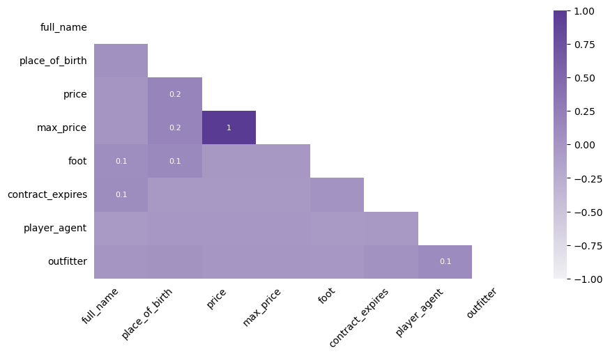

```python
import missingno as msno
import seaborn as sns
import matplotlib.pyplot as plt

# cria um colormap que vai de branco à sua cor
custom_cmap = sns.light_palette("#593B94", as_cmap=True)

msno.heatmap(
    df,
    figsize=(10,5),
    fontsize=10,
    cmap=custom_cmap
)
plt.show()
```

Aqui, geramos um `heatmap` que demonstra a correlação de `missing values` entre as variáveis.

Observando o gráfico gerado, as variáveis `max_price` e `price` apresentam correlação `1`, ou seja, sempre que uma dessas variáveis tem um valor ausente, a outra também tem — em todas as ocorrências.

[figure not shown]

```python
df.hist(bins='sturges',
        color='#BAA5E2',
        figsize=(13,8));
```

Este comando gera histogramas para todas as variáveis, ajudando a entender a distribuição de cada uma delas.

```python
df = df.drop(columns=["Unnamed: 0"])
```

Variável desconsiderada no df.

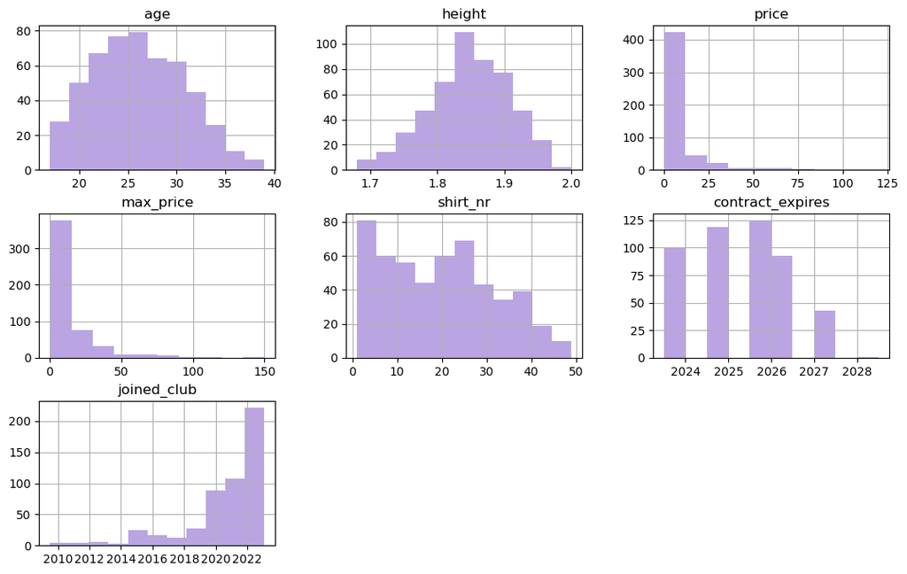

```python
df.hist(bins='sturges',
        color='#BAA5E2',
        figsize=(13,8));
```

Através do histograma, podemos tirar insights importantes para o projeto e que podem ajudar no entendimento dos dados. Vamos analisar cada variável:

#### 👀 4. Compreensão das variáveis e seus comportamentos

##### 4.1 `Age`: frequência da Idade dos jogadores:

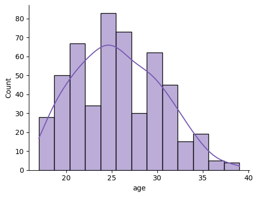

```python
sns.displot(df,
            x="age",
            kde=True,
            height=4,
            aspect=1.3,
            color='#785AB3')
```

```python
df['age'].describe()
```

```
count    515.000000
mean      25.683495
std        4.700238
min       17.000000
25%       22.000000
50%       25.000000
75%       29.000000
max       39.000000
Name: age, dtype: float64
```

Aliando o `histograma` ao `describe`, temos uma visualização gráfica e um conjunto de estatísticas descritivas básicas da variável.  
Assim, podemos interpretar que:

- Temos 515 registros de idades válidas (todo o df);
- A idade média dos jogadores é de aproximadamente 25,68 anos;
- A maioria das idades fica dentro de ±4,7 anos da média;
- Idade mínima = 17 anos;
- Idade máxima = 39 anos;
- 25% das idades são menores ou iguais a 22 anos;
- Metade das idades está abaixo ou igual a 25 anos;
- 75% das idades são menores ou iguais a 29 anos.

##### 4.2 `Price`:

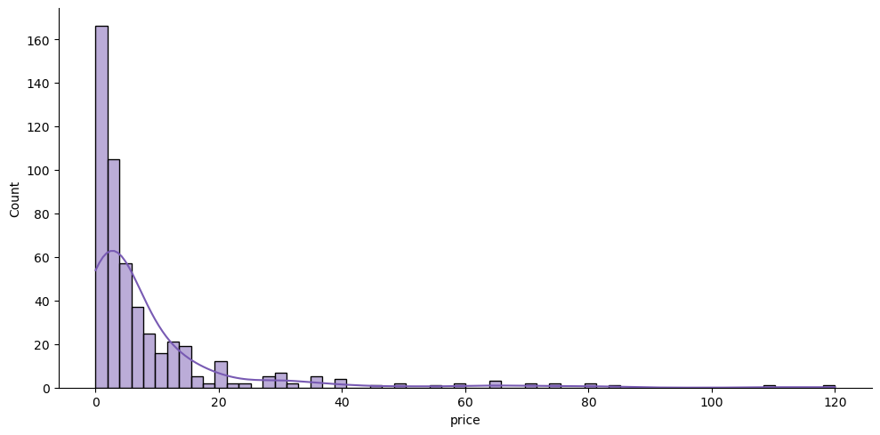

```python
sns.displot(df,
            x="price",
            kde=True,
            height=5,
            aspect=2,
            color='#785AB3')
```

```python
df['price'].describe()
```

```
count    510.000000
mean       8.482794
std       14.653440
min        0.025000
25%        1.200000
50%        3.500000
75%        9.000000
max      120.000000
Name: price, dtype: float64
```

Aliando o `histograma` ao `describe`, temos uma visualização gráfica e um conjunto de estatísticas descritivas básicas da variável. Assim, podemos interpretar que:

- Temos 510 registros de valores válidos;
- O preço médio é de aproximadamente 8,48 M (milhões);
- A dispersão em torno da média (desvio-padrão) é alta, cerca de 14,65, indicando bastante variabilidade;
- Preço mínimo observado = 0,025 M;
- Preço máximo observado = 120 M;
- 25% dos valores são menores ou iguais a 1,20 M;
- A mediana (50%) está em 3,50 M, ou seja, metade dos casos tem valor até esse ponto;
- 75% dos valores são menores ou iguais a 9,00 M.

Percebemos aqui uma forte assimetria à direita (skew), com alguns valores bem altos (até 120 M) puxando a média para cima.

```python
# Correlação de Pearson entre price e max_price
corr_pearson = df['price'].corr(df['max_price'])
print(f"Correlação (Pearson) entre price e max_price: {corr_pearson:.3f}")

# Ou, para ver uma matriz de correlação de várias colunas:
print(df[['price', 'max_price']].corr())
```

```
Correlação (Pearson) entre price e max_price: 0.871
              price  max_price
price      1.000000   0.871134
max_price  0.871134   1.000000
```

Visto que semanticamente as variáveis `price` e `max_price` possuem relação, assim como a relação identificada para os missing values, calculamos a correlação e podemos observar um alto nível apresentado.

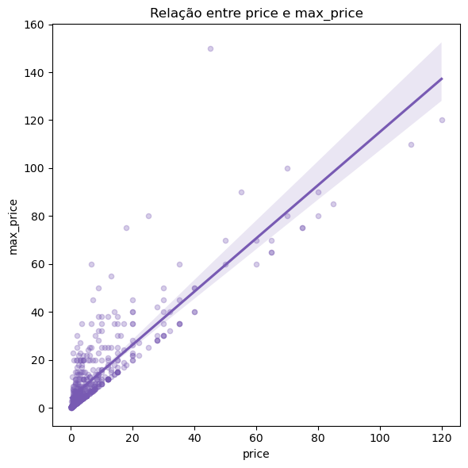

```python
import matplotlib.pyplot as plt
import seaborn as sns

plt.figure(figsize=(6,6))
sns.regplot(
    x='price',
    y='max_price',
    data=df,
    color='#785AB3',
    scatter_kws={'alpha':0.3, 's':20},
)
plt.title('Relação entre price e max_price')
plt.xlabel('price')
plt.ylabel('max_price')
plt.tight_layout()
plt.show()
```

Plotando os resultados, podemos visualizar como as variáveis se relacionam, e podemos observar um aumento da margem de erro para preços mais altos.

##### 4.3 `Height`:

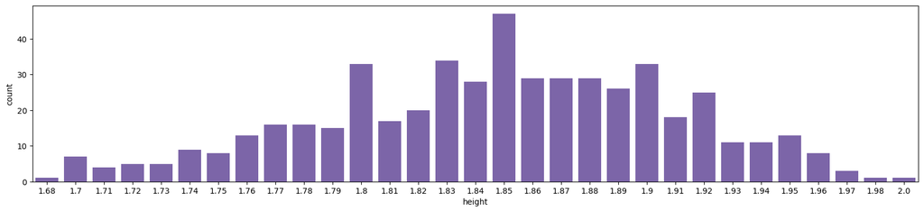

```python
# Pega os valores de height, ordena e remove duplicatas para eixo X
ordered_vals = np.sort(df['height'].unique())

plt.figure(figsize=(20,4))
sns.countplot(
    x='height',
    data=df,
    order=ordered_vals,
    color='#785AB3'
)
```

```python
df['height'].describe()
```

```
count    515.000000
mean       1.847612
std        0.060996
min        1.680000
25%        1.800000
50%        1.850000
75%        1.890000
max        2.000000
Name: height, dtype: float64
```

Aliando o `histograma` ao `describe`, temos uma visualização gráfica e um conjunto de estatísticas descritivas básicas da variável. Assim, podemos interpretar que:

- Temos 515 registros de valores válidos;
- A altura média é de aproximadamente 1,85 m;
- A dispersão em torno da média (desvio-padrão) é baixa, cerca de 0,06 m, indicando pouca variabilidade;
- Altura mínima observada = 1,68 m;
- Altura máxima observada = 2,00 m;
- 25% das alturas são menores ou iguais a 1,80 m;
- A mediana (50%) está em 1,85 m, ou seja, metade das observações tem altura até esse ponto;
- 75% das alturas são menores ou iguais a 1,89 m.

Observa-se uma distribuição aproximadamente simétrica, concentrada em torno de 1,85 m, sem caudas acentuadas nem valores extremos influenciando muito a média.

```python
(df[df['height'] == 1.68])
```

|  | name | full_name | age | height | nationality | place_of_birth | price | max_price | position | shirt_nr | foot | club | contract_expires | joined_club | player_agent | outfitter |
| --- | --- | --- | --- | --- | --- | --- | --- | --- | --- | --- | --- | --- | --- | --- | --- | --- |
| 449 | Romano Schmid | NaN | 23 | 1.68 | Austria | Graz | 4.5 | 5.0 | midfield - Attacking Midfield | 20 | right | Werder Bremen | 2025-06-30 | 2019-01-03 | YOU FIRST | adidas |

Aqui verificamos a(s) ocorrência(s) para a `menor altura` do nosso df.

```python
(df[df['height'] == 2.0])
```

|  | name | full_name | age | height | nationality | place_of_birth | price | max_price | position | shirt_nr | foot | club | contract_expires | joined_club | player_agent | outfitter |
| --- | --- | --- | --- | --- | --- | --- | --- | --- | --- | --- | --- | --- | --- | --- | --- | --- |
| 314 | Florian Schock | NaN | 21 | 2.0 | Germany | Ostfildern | 0.2 | 0.2 | Goalkeeper | 42 | right | VfB Stuttgart | 2024-06-30 | 2021-09-07 | Relatives | NaN |

Aqui verificamos a(s) ocorrência(s) para a `maior altura` do nosso df.

#### 👀 5. Exploração do dataframe e geração de insights

Agora que já analisamos as variáveis numéricas individualmente, vamos explorar um pouco mais as correlações.

##### 5.1 BoxSplot do preço dos jogadores por clube:

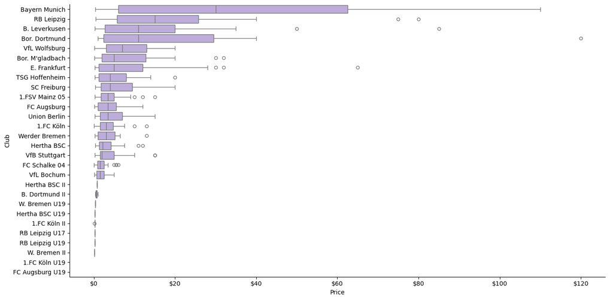

```python
# ordena pelos preços medianos
ordered_clubs = df.groupby("club")["price"] \
                  .median() \
                  .sort_values(ascending=False) \
                  .index

# plota o boxplot horizontal
sns.catplot(
    data=df,
    x="price", y="club",
    kind="box", orient="h",
    order=ordered_clubs,
    color='#BAA5E2',
    height=7, aspect=2
).set_axis_labels("Price", "Club")

# formata os ticks do eixo X como moeda
ax = plt.gca()
ax.xaxis.set_major_formatter(StrMethodFormatter('${x:,.0f}'))

plt.tight_layout()
plt.show()
```

Aqui observamos, conforme previsto conhecendo um pouco a respeito do futebol alemão, que o clube `Bayern Munich` apresenta a maior média de preço dos jogadores em seu elenco, sendo portanto o time mais "valioso" da Bundesliga (liga alemã).

```python
(df[df['club'] == 'Bayern Munich'])
```

|  | name | full_name | age | height | nationality | place_of_birth | price | max_price | position | shirt_nr | foot | club | contract_expires | joined_club | player_agent | outfitter |
| --- | --- | --- | --- | --- | --- | --- | --- | --- | --- | --- | --- | --- | --- | --- | --- | --- |
| 0 | Manuel Neuer | Manuel Peter Neuer | 37 | 1.93 | Germany | Gelsenkirchen | 7.0 | 45.0 | Goalkeeper | 1 | right | Bayern Munich | 2024-06-30 | 2011-07-01 | PRO Profil GmbH | adidas |
| 1 | Yann Sommer | NaN | 34 | 1.83 | Switzerland | Morges | 5.0 | 13.0 | Goalkeeper | 27 | right | Bayern Munich | 2025-06-30 | 2023-01-19 | Relatives | Puma |
| 2 | Sven Ulreich | NaN | 34 | 1.92 | Germany | Schorndorf | 0.9 | 6.0 | Goalkeeper | 26 | right | Bayern Munich | 2024-06-30 | 2021-07-01 | BMS Sportconsulting ... | adidas |
| 3 | Johannes Schenk | NaN | 20 | 1.91 | Germany | Schweinfurt | 0.3 | 0.3 | Goalkeeper | 35 | NaN | Bayern Munich | 2024-06-30 | 2022-07-01 | 11WINS | NaN |
| 4 | Matthijs de Ligt | NaN | 23 | 1.89 | Netherlands | Leiderdorp | 75.0 | 75.0 | Defender - Centre-Back | 4 | right | Bayern Munich | 2027-06-30 | 2022-07-19 | Rafaela Pimenta | adidas |
| 5 | Dayot Upamecano | Dayotchanculle Oswald Upamecano | 24 | 1.86 | France Guinea-Bissau | Évreux | 60.0 | 60.0 | Defender - Centre-Back | 2 | right | Bayern Munich | 2026-06-30 | 2021-07-05 | Unique Sports Group | Nike |
| 6 | Lucas Hernández | Lucas François Bernard Hernández Pi | 27 | 1.84 | France Spain | Marseille | 50.0 | 70.0 | Defender - Centre-Back | 21 | left | Bayern Munich | 2024-06-30 | 2019-07-01 | Manuel García ... | Nike |
| 7 | Alphonso Davies | Alphonso Boyle Davies | 22 | 1.85 | Canada Liberia | Buduburam | 70.0 | 80.0 | Defender - Left-Back | 19 | left | Bayern Munich | 2025-06-30 | 2019-01-01 | ATG Sports | NaN |
| 8 | Daley Blind | NaN | 33 | 1.80 | Netherlands | Amsterdam | 6.0 | 25.0 | Defender - Left-Back | 23 | left | Bayern Munich | 2023-06-30 | 2023-01-05 | SEG | adidas |
| 9 | João Cancelo | João Pedro Cavaco Cancelo | 28 | 1.82 | Portugal | Barreiro | 60.0 | 70.0 | Defender - Right-Back | 22 | right | Bayern Munich | 2023-06-30 | 2023-01-31 | Gestifute | Nike |
| 10 | Benjamin Pavard | NaN | 27 | 1.86 | France | Maubeuge | 35.0 | 45.0 | Defender - Right-Back | 5 | right | Bayern Munich | 2024-06-30 | 2019-07-01 | Carmenta | adidas |
| 11 | Noussair Mazraoui | نصير مزراوي | 25 | 1.83 | Morocco Netherlands | Leiderdorp | 28.0 | 28.0 | Defender - Right-Back | 40 | right | Bayern Munich | 2026-06-30 | 2022-07-01 | Rafaela Pimenta | adidas |
| 12 | Josip Stanisic | Josip Stanišić | 23 | 1.87 | Croatia Germany | München | 12.0 | 12.0 | Defender - Right-Back | 44 | both | Bayern Munich | 2026-06-30 | 2021-08-01 | BALLWERK Sports GmbH | adidas |
| 13 | Bouna Sarr | NaN | 31 | 1.77 | Senegal France | Lyon | 2.5 | 9.0 | Defender - Right-Back | 20 | right | Bayern Munich | 2024-06-30 | 2020-10-05 | Wasserman | NaN |
| 14 | Joshua Kimmich | Joshua Walter Kimmich | 28 | 1.77 | Germany | Rottweil | 80.0 | 90.0 | midfield - Defensive Midfield | 6 | right | Bayern Munich | 2025-06-30 | 2015-07-02 | NaN | NaN |
| 15 | Leon Goretzka | Leon Christoph Goretzka | 28 | 1.89 | Germany | Bochum | 65.0 | 70.0 | midfield - Central Midfield | 8 | right | Bayern Munich | 2026-06-30 | 2018-07-01 | Neubauer 13 GmbH | NaN |
| 16 | Ryan Gravenberch | Ryan Jiro Gravenberch | 20 | 1.90 | Netherlands Suriname | Amsterdam | 30.0 | 35.0 | midfield - Central Midfield | 38 | right | Bayern Munich | 2027-06-30 | 2022-07-01 | Team Raiola | adidas |
| 17 | Jamal Musiala | NaN | 20 | 1.84 | Germany England | Stuttgart | 110.0 | 110.0 | midfield - Attacking Midfield | 42 | right | Bayern Munich | 2026-06-30 | 2020-07-01 | 11WINS | NaN |
| 18 | Paul Wanner | NaN | 17 | 1.85 | Germany Austria | Dornbirn | 3.0 | 3.0 | midfield - Attacking Midfield | 14 | left | Bayern Munich | 2027-06-30 | 2022-01-31 | Agent is known - Player under 18 | adidas |
| 19 | Arijon Ibrahimovic | Arijon Ibrahimović / Arijon Ibrahimi | 17 | 1.76 | Germany Kosovo | Nürnberg | 1.0 | 1.0 | midfield - Attacking Midfield | 46 | right | Bayern Munich | 2025-06-30 | 2023-01-17 | Agent is known - Player under 18 | NaN |
| 20 | Kingsley Coman | Kingsley Junior Coman | 26 | 1.81 | France Guadeloupe | Paris | 65.0 | 65.0 | Attack - Left Winger | 11 | right | Bayern Munich | 2027-06-30 | 2017-07-01 | CAA Base Ltd | Nike |
| 21 | Sadio Mané | NaN | 31 | 1.74 | Senegal | Bambaly | 45.0 | 150.0 | Attack - Left Winger | 17 | right | Bayern Munich | 2025-06-30 | 2022-07-01 | ROOF | New Balance |
| 22 | Leroy Sané | Leroy Aziz Sané | 27 | 1.83 | Germany France | Essen | 70.0 | 100.0 | Attack - Right Winger | 10 | left | Bayern Munich | 2025-06-30 | 2020-07-15 | LIAN Sports Group | Nike |
| 23 | Serge Gnabry | Serge David Gnabry | 27 | 1.76 | Germany Cote d'Ivoire | Stuttgart | 55.0 | 90.0 | Attack - Right Winger | 7 | right | Bayern Munich | 2026-06-30 | 2017-07-01 | ROOF | adidas |
| 24 | Thomas Müller | NaN | 33 | 1.85 | Germany | Weilheim in Oberbayern | 18.0 | 75.0 | Attack - Second Striker | 25 | right | Bayern Munich | 2024-06-30 | 2009-07-01 | Kögl & Partner GmbH | adidas |
| 25 | Mathys Tel | NaN | 18 | 1.83 | France Guadeloupe | Sarcelles | 20.0 | 20.0 | Attack - Centre-Forward | 39 | right | Bayern Munich | 2025-06-30 | 2022-07-26 | NaN | NaN |
| 26 | Eric Maxim Choupo-Moting | Eric Maxim Choupo-Moting | 34 | 1.91 | Cameroon Germany | Hamburg | 6.0 | 10.0 | Attack - Centre-Forward | 13 | right | Bayern Munich | 2024-06-30 | 2020-10-05 | ROGON | Puma |

Aqui, visualizamos um pouco do nosso dataframe considerando o time `Bayern Munich`

No gráfico gerado do preço dos jogadores por clube, podemos evidenciar também, através dos círculos "perdidos", a existência de outliers (pontos fora da curva) que demonstram que alguns clubes possuem jogadores muito acima da média de preços em relação ao próprio elenco, vamos conhecê-los.

```python
(df.nlargest(5, 'price'))
```

|  | name | full_name | age | height | nationality | place_of_birth | price | max_price | position | shirt_nr | foot | club | contract_expires | joined_club | player_agent | outfitter |
| --- | --- | --- | --- | --- | --- | --- | --- | --- | --- | --- | --- | --- | --- | --- | --- | --- |
| 47 | Jude Bellingham | Jude Victor William Bellingham | 19 | 1.86 | England | Stourbridge | 120.0 | 120.0 | midfield - Central Midfield | 22 | right | Bor. Dortmund | 2025-06-30 | 2020-07-23 | NaN | adidas |
| 17 | Jamal Musiala | NaN | 20 | 1.84 | Germany England | Stuttgart | 110.0 | 110.0 | midfield - Attacking Midfield | 42 | right | Bayern Munich | 2026-06-30 | 2020-07-01 | 11WINS | NaN |
| 106 | Florian Wirtz | Florian Richard Wirtz | 20 | 1.76 | Germany | Pulheim | 85.0 | 85.0 | midfield - Attacking Midfield | 27 | right | B. Leverkusen | 2027-06-30 | 2020-07-01 | Relatives | adidas |
| 14 | Joshua Kimmich | Joshua Walter Kimmich | 28 | 1.77 | Germany | Rottweil | 80.0 | 90.0 | midfield - Defensive Midfield | 6 | right | Bayern Munich | 2025-06-30 | 2015-07-02 | NaN | NaN |
| 83 | Christopher Nkunku | Christopher Alan Nkunku | 25 | 1.78 | France DR Congo | Lagny-sur-Marne | 80.0 | 80.0 | Attack - Second Striker | 18 | right | RB Leipzig | 2026-06-30 | 2019-07-18 | Gol International | adidas |

##### 5.2 ScatterPlot do preço dos jogadores por faixa etária:

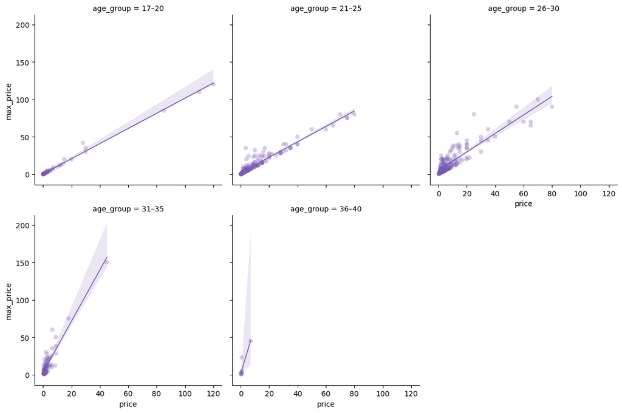

```python
# Cria faixas fixas de idade
df["age_group"] = pd.cut(
    df["age"],
    bins=[17, 20, 25, 30, 35, 40],
    labels=["17–20","21–25","26–30","31–35","36–40"],
    include_lowest=True
)

# Cria um scatterplot facetado por age_group
g = sns.relplot(
    data=df,
    x="price", y="max_price",
    col="age_group", col_wrap=3,
    kind="scatter",
    color="#785AB3",
    alpha=0.3,
    edgecolor="none",
    height=4, aspect=1
)

# Sobrepõe linha de tendência em cada faceta
g.map(
    sns.regplot,
    "price", "max_price",
    scatter=False,
    color="#785AB3",
    line_kws={'linewidth': 1.2}
)
```

Aqui, podemos observar que faixas etárias menores apresentam uma correlação próxima a 1 entre `price` e `max_price`, indicando que esses jogadores estão avaliados, em média, próximos ao seu preço máximo. Em contrapartida, podemos perceber que as últimas faixas etárias apresentam justamente o oposto, onde o `max_price` já não representa o `price` dos jogadores, e sim, um valor superior ao valor atual do jogador.

##### 5.3 Tabela de média de idade e número de ocorrências por posição

```python
# Faz a contagem das ocorrências da variável position
counts = df['position'].value_counts()

print(counts)
```

```
position
Defender - Centre-Back           88
Attack - Centre-Forward          73
Goalkeeper                       69
midfield - Central Midfield      56
Defender - Right-Back            44
Defender - Left-Back             40
midfield - Defensive Midfield    40
midfield - Attacking Midfield    40
Attack - Right Winger            30
Attack - Left Winger             22
Attack - Second Striker           7
midfield - Right Midfield         4
midfield - Left Midfield          2
Name: count, dtype: int64
```

Para a tabela, irei considerar 4 grupos de posições, sendo eles goleiro, defensor, meio campista e atacante.

```python
# Cria uma nova coluna group_position
df['position_group'] = df['position'].str.partition(' ')[0]

df[['position', 'position_group']].head(10)
```

|  | position | position_group |
| --- | --- | --- |
| 0 | Goalkeeper | Goalkeeper |
| 1 | Goalkeeper | Goalkeeper |
| 2 | Goalkeeper | Goalkeeper |
| 3 | Goalkeeper | Goalkeeper |
| 4 | Defender - Centre-Back | Defender |
| 5 | Defender - Centre-Back | Defender |
| 6 | Defender - Centre-Back | Defender |
| 7 | Defender - Left-Back | Defender |
| 8 | Defender - Left-Back | Defender |
| 9 | Defender - Right-Back | Defender |

Agora, geramos a tabela com os resultados.

```python
# Agrupa por position_group e calcula média de idade e contagem de ocorrências
df_position = (
    df
    .groupby('position_group')['age']
    .agg(
        average_age = 'mean',
        occurrences  = 'size'
    )
    .reset_index()
    .sort_values('average_age', ascending=False)
)

df_position
```

|  | position_group | average_age | occurrences |
| --- | --- | --- | --- |
| 2 | Goalkeeper | 27.159420 | 69 |
| 1 | Defender | 25.761628 | 172 |
| 0 | Attack | 25.530303 | 132 |
| 3 | midfield | 25.014085 | 142 |

Goleiros tendem a ser, aproximadamente de 1 a 2 anos mais velhos em média, do que jogadores de outras posições.

##### 5.3 Tabela de média de preço e número de ocorrências por posição

```python
# Agrupa por position_group e calcula média de idade e contagem de ocorrências
df_price = (
    df
    .groupby('position_group')['price']
    .agg(
        average_price = 'mean',
        occurrences  = 'size'
    )
    .reset_index()
    .sort_values('average_price', ascending=False)
)

df_price
```

|  | position_group | average_price | occurrences |
| --- | --- | --- | --- |
| 3 | midfield | 9.874468 | 142 |
| 0 | Attack | 9.717176 | 132 |
| 1 | Defender | 8.923824 | 172 |
| 2 | Goalkeeper | 2.116544 | 69 |

Goleiros apresentam valores médios muito inferiores em relação a jogadores de outras posições.

```python
df.to_csv('df_tratado.csv', index=False)  # index=False para não exportar o índice
```